# Vignette Title: test

15 September 2022

#### Package

# 1 Getting started

To enable the *Bioconductor* style in your R Markdown vignette you need to include the following in the `DESCRIPTION` file:

```
VignetteBuilder: knitr
Suggests: BiocStyle, knitr, rmarkdown
```

# 2 Style macros

*BiocStyle* introduces the following macros for referring to *R* packages:

- *IRanges*, for *Bioconductor* software, annotation and experiment data packages,
- *data.table*, for *R* packages available on CRAN,
- *rmarkdown*, for *R* packages available on GitHub,
- *MyPkg*, for *R* packages that are *not* available on *Bioconductor*, CRAN or GitHub.

# 3 Figures

Assign captions to figures in the code chunk option `fig.cap` to automatically number them, and to be able to reference them, see Figure 1. The figure label is generated from the code chunk label by prefixing it with `fig:`.

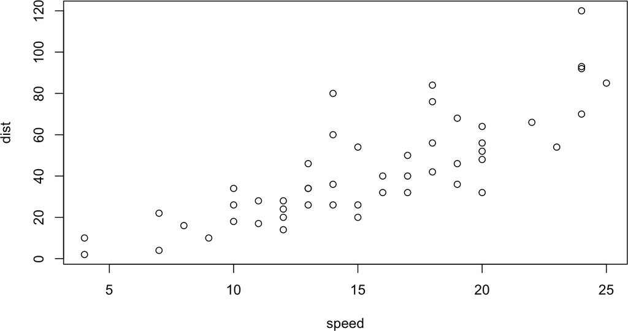

Figure 1: Regular figure  
The first sentence of the figure caption is automatically emphasized to serve as figure title.

Small and wide figures can be specified by `fig.small` and `fig.wide` code chunk options.

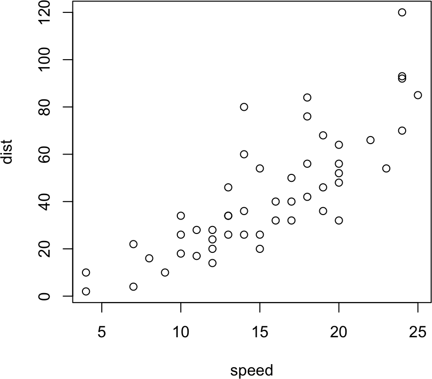

Figure 2: Small figure  
A plot produced by a code chunk with option `fig.small = TRUE`.

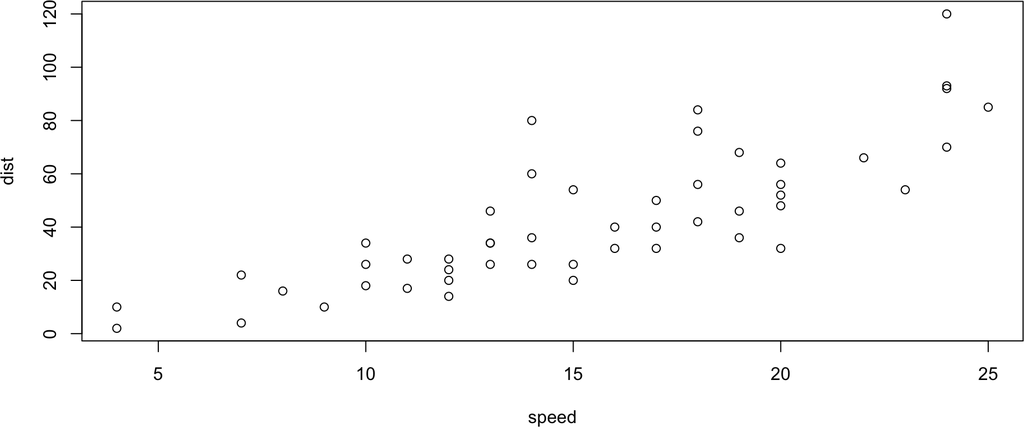

Figure 3: Wide figure  
A plot produced by a code chunk with option `fig.wide = TRUE`.

# 4 Equations

To number and reference equations, put them in equation environments and assign labels to them, see Equation (1).

$$\begin{equation}
f\left(k\right) = \binom{n}{k} p^k\left(1-p\right)^{n-k}
\tag{1}
\end{equation}$$

# 5 Tables

Like figures, tables with captions will also be numbered and can be referenced, see Table 1.

Table 1: A simple table With caption.

| Fruit | Price |
| --- | --- |
| bananas | 1.2 |
| apples | 1.0 |
| oranges | 2.5 |

# 6 Cross-references

Apart from referencing figures (Section 3), tables (Section 5), and equations (Section 4), you can also use the same syntax to refer to sections by their default labels generated by pandoc.

# 7 Side notes

Footnotes are displayed as side notes on the right margin, which has the advantage that they appear close to the place where they are defined.

this is a side note entered as a footnote